# Assignment D

## Instructions

1. You may talk to a friend, discuss the questions and potential directions for solving them. However, you need to write your own solutions and code separately, and not as a group activity.
2. Do not write your name on the assignment.
3. Write your code in the *Code* cells and your answer in the *Markdown* cells of the Jupyter notebook. Ensure that the solution is written neatly enough to understand and grade.
4. Use [Quarto](https://quarto.org/docs/output-formats/html-basics.html) to print the *.ipynb* file as HTML. You will need to open the command prompt, navigate to the directory containing the file, and use the command: `quarto render filename.ipynb --to html`. Submit the HTML file.
5. The assignment is worth 100 points, and is due on **Tuesday, 21st February 2023 at 11:59 pm**.
6. **Five points are properly formatting the assignment**. The breakdown is as follows:
- Must be an HTML file rendered using Quarto (1 pt). *If you have a Quarto issue, you must mention the issue & quote the error you get when rendering using Quarto in the comments section of Canvas, and submit the ipynb file.*
- No name can be written on the assignment, nor can there be any indicator of the student’s identity—e.g. printouts of the working directory should not be included in the final submission (1 pt)
- There aren’t excessively long outputs of extraneous information (e.g. no printouts of entire data frames without good reason, there aren’t long printouts of which iteration a loop is on, there aren’t long sections of commented-out code, etc.) (1 pt)
- Final answers of each question are written in Markdown cells (1 pt).
- There is no piece of unnecessary / redundant code, and no unnecessary / redundant text (1 pt)

```python
import pandas as pd
import numpy as np
import seaborn as sns
import matplotlib.pyplot as plt
import statsmodels.formula.api as smf
```

## Data description

The data is related with direct marketing campaigns of a Portuguese banking institution. The marketing campaigns were based on phone calls, where bank clients were called to subscribe for a term deposit.

There is one train data - *train.csv*, which you will use to develop a model. There are two test datasets - *test1.csv* and *test2.csv*, which you will use to test your model. Each dataset has the following attributes about the clients called in the marketing campaign:

1. `age`: Age of the client
2. `education`: Education level of the client
3. `day`: Day of the month the call is made
4. `month`: Month of the call
5. `y`: did the client subscribe to a term deposit?
6. `duration`: Call duration, in seconds. This attribute highly affects the output target (e.g., if duration=0 then y=‘no’). Yet, the `duration` is not known before a call is performed. Also, after the end of the call `y` is obviously known. Thus, this input should only be included for inference purposes and should be discarded if the intention is to have a realistic predictive model.

(Raw data source: [Source](https://archive.ics.uci.edu/ml/datasets/bank+marketing). Do not use the raw data source for this assingment. It is just for reference.)

## Instructions / suggestions for answering questions

1. **Instruction:** Use *train.csv* for all questions, unless otherwise stated.
2. **Suggestion 1:** You may use the functions in the class notes for printing the confusion matrix and the overall classification accuracy based on test / train data.
3. **Suggestion 2:**: If you make variable transformations, you will need to do it for all the three datasets. Your code will be a bit concise if you make a function containing all the transformations, and then call it for the training and the two test datasets. You can put this function in the beginning of the code and keep adding transformations to it as you proceed with the assignment. You may need transformations in questions (1) and (13).

## D.1 Probability of response vs call duration

Read the datasets. Make an appropriate visualization to visualize how the proportion of clients subscribing to a term deposit change with increasing call duration.

*(4 points)*

**Hints**:

1. Bin `duration` to create `duration_binned`. Group the data to find the fraction of clients responding positively to the marketing campaign for each bin in `duration_binned`. Make a lineplot of percentage of clients subscribing to a term deposit vs `duration_binned`, where the bins in `duration_binned` are arranged in increasing order of duration.
2. You may choose an appropriate number of bins & type of binning that helps you visualize well.
3. You may also think of other ways of visualization. You don’t need to stick with this one.

```python
train = pd.read_csv('train-2.csv')
test1 = pd.read_csv('test1.csv')
test2 = pd.read_csv('test2.csv')
```

```python
train['duration_binned'] = pd.qcut(train['duration'], q=10, labels=False)
train['y'] = train['y'].apply(lambda x: 1 if x == 'yes' else 0)
train_grouped = train.groupby('duration_binned').mean()
```

```python
test1['duration_binned'] = pd.qcut(test1['duration'], q=10, labels=False)
test1['y'] = test1['y'].apply(lambda x: 1 if x == 'yes' else 0)
```

```python
test2['duration_binned'] = pd.qcut(test2['duration'], q=10, labels=False)
test2['y'] = test2['y'].apply(lambda x: 1 if x == 'yes' else 0)
```

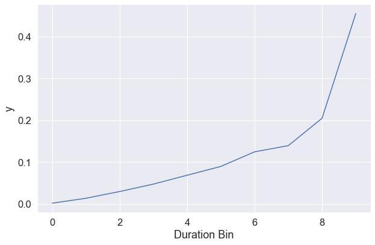

```python
sns.lineplot(x = train_grouped.index, y= train_grouped['y'])
plt.xlabel('Duration Bin')
plt.show()
```

## D.2 Predictor `duration`

Based on the plot in D.1, comment whether `duration` seems to be a useful variable to predict if the client will subsribe to a term deposit.

*(1 point)*

## D.3 Model based on `duration`

Develop a logisitic regression model to predict if the client subscribed to a term deposit based on call `duration`. Use the model to make a lineplot showing the probability of the client subscribing to a term deposit based on call `duration`.

*(3 points)*

```
Optimization terminated successfully.
         Current function value: 0.305028
         Iterations 7
```

```
-10675.995307511752
```

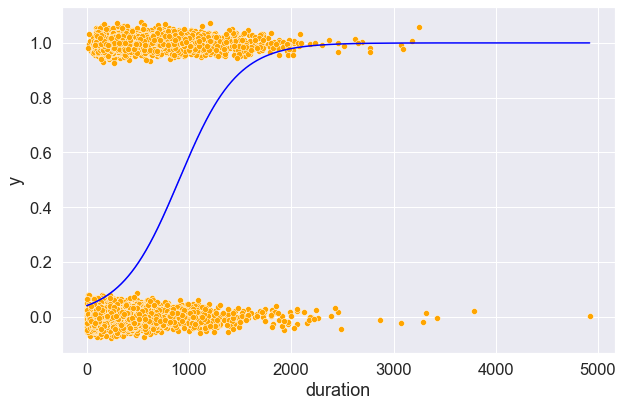

```python
def jitter(values,j):
    return values + np.random.normal(j,0.02,values.shape)
sns.scatterplot(x = jitter(train.duration,0), y = jitter(train.y,0), data = train, color = 'orange')
logit_model = smf.logit(formula = 'y~duration', data = train).fit()
sns.lineplot(x = 'duration', y= logit_model.predict(train), data = train, color = 'blue')
logit_model.llf
```

## Note {-}:

Answer questions D.4 to D.11 based on the regression model developed in D.3.

## D.4 Model significance

Is the regression model in statistically significant? Justify your answer.

*(1 point for code, 1 point for answer)*

```python
logit_model.summary()
```

Logit Regression Results

| Dep. Variable: | y | No. Observations: | 35000 |
| --- | --- | --- | --- |
| Model: | Logit | Df Residuals: | 34998 |
| Method: | MLE | Df Model: | 1 |
| Date: | Sun, 26 Feb 2023 | Pseudo R-squ.: | 0.1560 |
| Time: | 18:51:31 | Log-Likelihood: | -10676. |
| converged: | True | LL-Null: | -12650. |
| Covariance Type: | nonrobust | LLR p-value: | 0.000 |

|  | coef | std err | z | P>\|z\| | [0.025 | 0.975] |
| --- | --- | --- | --- | --- | --- | --- |
| Intercept | -3.1841 | 0.030 | -107.465 | 0.000 | -3.242 | -3.126 |
| duration | 0.0035 | 6.24e-05 | 56.446 | 0.000 | 0.003 | 0.004 |

#### Yes. The LLR p-value is 0 which is less than 0.05. Thus, the overall regression model is significant.

## D.5 Subscription probability in 5 minutes

What is the probability that the client subscribes to a term deposit with a 5-minute marketing call? Note that the call `duration` in data is given in *seconds*.

*(2 points)*

```python
duration = 5*60

# create a data frame with the values of the predictors
pred_data = pd.DataFrame({'duration':[duration]})

# make the prediction
pred_prob = logit_model.predict(pred_data)

# print the predicted probability of subscription
print("Predicted probability of subscription:", pred_prob[0])
```

```
Predicted probability of subscription: 0.10649131158808794
```

#### Predicted probability of subscription: 0.10649131158808794

## D.6 Call duration for subscription

What is the minimum call duration (in minutes) for which a client has a 95% or higher chance of subscribing to a term deposit?

*(4 points)*

```python
for i in range(0,3600):
    pred_data = pd.DataFrame({'duration':[i]})
    pred_prob = logit_model.predict(pred_data)
    if pred_prob[0] < 0.95:
        continue
    else:
        print(i/60)
        print(pred_prob[0])
    break
```

```
29.0
0.9501009216423634
```

#### Minimum call duration: 29.0 minutes

## D.7 Maximum call duration

What is the maximum call duration (in minutes) in which a client refused to subscribe to a term deposit? What was the probability of the client subscribing to the term deposit in that call?

*(4 points)*

```python
no_subscription = train.loc[train['y']==0]
```

```python
no_subscription.sort_values(by='duration',ascending=False).head(1)
```

|  | age | education | day | month | y | duration | duration_binned |
| --- | --- | --- | --- | --- | --- | --- | --- |
| 34120 | 59 | tertiary | 10 | nov | 0 | 4918 | 9 |

```python
duration = 4918

# create a data frame with the values of the predictors
pred_data = pd.DataFrame({'duration':[duration]})

# make the prediction
pred_prob = logit_model.predict(pred_data)

# print the predicted probability of subscription
print("Maximum call duration in minutes without a subscription:", duration/60)
print("Predicted probability of subscription:", pred_prob[0])
```

```
Maximum call duration in minutes without a subscription: 81.96666666666667
Predicted probability of subscription: 0.9999992798803662
```

#### Maximum call duration in minutes without a subscription: 81.96666666666667 minutes

#### Predicted probability of subscription: 0.9999992798803662

## D.8 Percent increase in odds

What is the percentage increase in the odds of a client suscribing to a term deposit when the call `duration` increases by a minute?

*(4 points)*

```python
coeff = logit_model.params[1]*60
percentage_odds_increase = (np.exp(coeff) - 1)*100
percentage_odds_increase
```

```
23.540942175386583
```

#### Percentage odds increase: 23.540942175386583%

## D.9 Doubling the subscription odds

How much must the call `duration` increase (in minutes) so that it doubles the odds of the client subscribing to a term deposit.

*(3 points)*

```python
# Coefficient for duration variable
coef_duration = logit_model.params[1]

# Calculate increase in call duration needed to double odds
x = (np.log(2)) / (coef_duration * 60)

print(f"The call duration must increase by approximately {x:.1f} minutes to double the odds of subscribing to a term deposit.")
```

```
The call duration must increase by approximately 3.3 minutes to double the odds of subscribing to a term deposit.
```

#### The call duration must increase by approximately 3.3 minutes to double the odds of subscribing to a term deposit.

## D.10 Classification accuracy

What is minimum overall classification accuracy of the model among the classification accuracies on *train.csv*, *test1.csv* and *test2.csv*? Consider a threshold of 30% when classifying observations.

*(2 + 1 + 1 points)*

```python
def confusion_matrix_train(model,cutoff=0.5):
    # Confusion matrix
    cm_df = pd.DataFrame(model.pred_table(threshold = cutoff))
    #Formatting the confusion matrix
    cm_df.columns = ['Predicted 0', 'Predicted 1']
    cm_df = cm_df.rename(index={0: 'Actual 0',1: 'Actual 1'})
    cm = np.array(cm_df)
    # Calculate the accuracy
    accuracy = (cm[0,0]+cm[1,1])/cm.sum()
    sns.heatmap(cm_df, annot=True, cmap='Blues', fmt='g')
    plt.ylabel("Actual Values")
    plt.xlabel("Predicted Values")
    print("Classification accuracy = {:.1%}".format(accuracy))
```

```
Classification accuracy = 88.5%
```

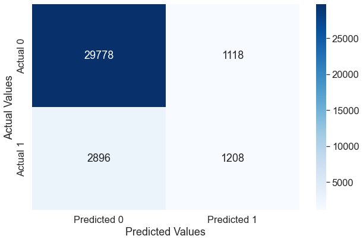

```python
cm = confusion_matrix_train(logit_model,cutoff=0.3)
```

```python
def confusion_matrix_test(data,actual_values,model,cutoff=0.5):
#Predict the values using the Logit model
    pred_values = model.predict(data)
# Specify the bins
    bins=np.array([0,cutoff,1])
#Confusion matrix
    cm = np.histogram2d(actual_values, pred_values, bins=bins)[0]
    cm_df = pd.DataFrame(cm)
    cm_df.columns = ['Predicted 0','Predicted 1']
    cm_df = cm_df.rename(index={0: 'Actual 0',1:'Actual 1'})
    accuracy = (cm[0,0]+cm[1,1])/cm.sum()
    sns.heatmap(cm_df, annot=True, cmap='Blues', fmt='g')
    plt.ylabel("Actual Values")
    plt.xlabel("Predicted Values")
    print("Classification accuracy = {:.1%}".format(accuracy))
```

```
Classification accuracy = 88.4%
```

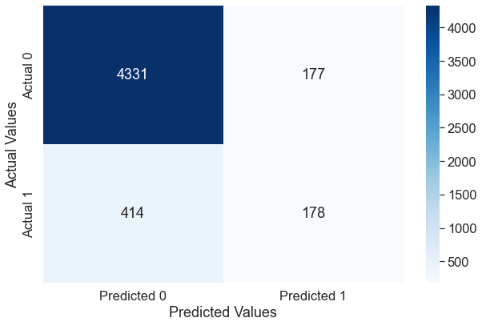

```python
confusion_matrix_test(test1,test1.y,logit_model,cutoff=0.3)
```

```
Classification accuracy = 88.6%
```

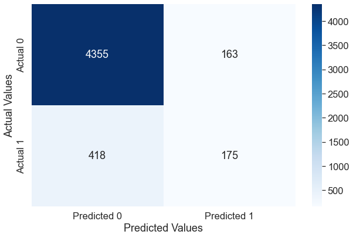

```python
confusion_matrix_test(test2,test2.y,logit_model,cutoff=0.3)
```

#### The minimum classification accuracy of the model among the three datasets belongs to the first test dataset.

## D.11 Recall

What is the minimum *Recall* of the model among the *Recall* performance on *train.csv*, *test1.csv* and *test2.csv*? Consider a decision threshold probability of 30% when classifying observations.

Here, *Recall* is the proportion of clients predicted to subscribe to a term deposit among those who actually subscribed.

*(3 points for code)*

```python
def confusion_matrix_data(data,actual_values,model,cutoff=0.5):
#Predict the values using the Logit model
    pred_values = model.predict(data)
# Specify the bins
    bins=np.array([0,cutoff,1])
#Confusion matrix
    cm = np.histogram2d(actual_values, pred_values, bins=bins)[0]
    cm_df = pd.DataFrame(cm)
    cm_df.columns = ['Predicted 0','Predicted 1']
    cm_df = cm_df.rename(index={0: 'Actual 0',1:'Actual 1'})
# Calculate the accuracy
    #accuracy = (cm[0,0]+cm[1,1])/cm.sum()
    #fnr = (cm[1,0])/(cm[1,0]+cm[1,1])
    #precision = (cm[1,1])/(cm[0,1]+cm[1,1])
    #fpr = (cm[0,1])/(cm[0,0]+cm[0,1])
    tpr = (cm[1,1])/(cm[1,0]+cm[1,1])
    #fpr_roc, tpr_roc, auc_thresholds = roc_curve(actual_values, pred_values)
    #auc_value = (auc(fpr_roc, tpr_roc))# AUC of ROC
    sns.heatmap(cm_df, annot=True, cmap='Blues', fmt='g')
    plt.ylabel("Actual Values")
    plt.xlabel("Predicted Values")
    #print("Classification accuracy = {:.1%}".format(accuracy))
    #print("Precision = {:.1%}".format(precision))
    print("TPR or Recall = {:.1%}".format(tpr))
    #print("FNR = {:.1%}".format(fnr))
    #print("FPR = {:.1%}".format(fpr))
    #print("ROC-AUC = {:.1%}".format(auc_value))
```

```
TPR or Recall = 29.4%
```

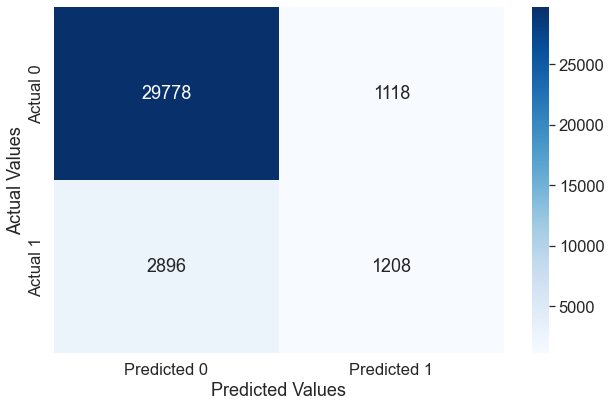

```python
confusion_matrix_data(train,train.y,logit_model,cutoff=0.3)
```

```
TPR or Recall = 30.1%
```

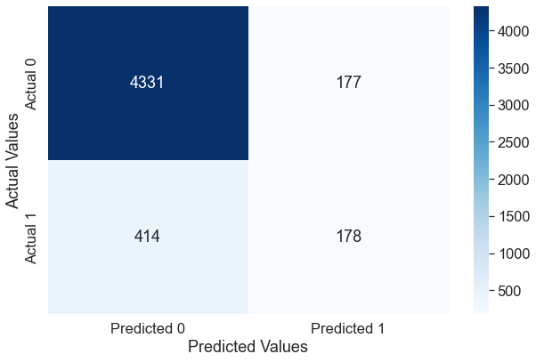

```python
confusion_matrix_data(test1,test1.y,logit_model,cutoff=0.3)
```

```
TPR or Recall = 29.5%
```

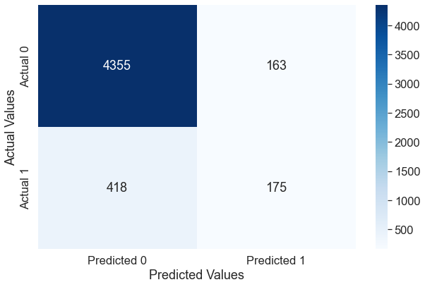

```python
confusion_matrix_data(test2,test2.y,logit_model,cutoff=0.3)
```

#### The minimum recall of the model among the the datasets is 29.4% from the training dataset.

## D.12 Subscription probability based on `age` and `education`

Develop a logistic regression model to predict the probability of a client subscribing to a term deposit based on `age`, `education` and the two-factor interaction between `age` and `education`. Based on the model, answer:

1. People with which type of `education` *(primary / secondary / tertiary / unknown)* have the highest percentage increase in odds of subscribing to a term deposit with a unit increase in `age`? Justify your answer.
2. What is the percentage increase in odds of a person subscribing to a term deposit for a unit increase in `age`, if the person has *tertiary* `education`.
3. What is the percentage increase in odds of a person subscribing to a term deposit for a unit increase in `age`, if the person has *primary* `education`.

*(1 point for developing the model, 3 points for (a), 3 points for (b), 3 points for (c))*

```python
logit_model = smf.logit(formula='y~age*education', data=train).fit()
logit_model.summary()
```

```
Optimization terminated successfully.
         Current function value: 0.356771
         Iterations 7
```

Logit Regression Results

| Dep. Variable: | y | No. Observations: | 35000 |
| --- | --- | --- | --- |
| Model: | Logit | Df Residuals: | 34992 |
| Method: | MLE | Df Model: | 7 |
| Date: | Sun, 26 Feb 2023 | Pseudo R-squ.: | 0.01288 |
| Time: | 18:51:56 | Log-Likelihood: | -12487. |
| converged: | True | LL-Null: | -12650. |
| Covariance Type: | nonrobust | LLR p-value: | 1.897e-66 |

|  | coef | std err | z | P>\|z\| | [0.025 | 0.975] |
| --- | --- | --- | --- | --- | --- | --- |
| Intercept | -4.6063 | 0.209 | -22.083 | 0.000 | -5.015 | -4.197 |
| education[T.secondary] | 2.1168 | 0.231 | 9.180 | 0.000 | 1.665 | 2.569 |
| education[T.tertiary] | 2.8103 | 0.238 | 11.832 | 0.000 | 2.345 | 3.276 |
| education[T.unknown] | 2.6776 | 0.359 | 7.455 | 0.000 | 1.974 | 3.382 |
| age | 0.0462 | 0.004 | 11.636 | 0.000 | 0.038 | 0.054 |
| age:education[T.secondary] | -0.0371 | 0.005 | -8.063 | 0.000 | -0.046 | -0.028 |
| age:education[T.tertiary] | -0.0447 | 0.005 | -9.230 | 0.000 | -0.054 | -0.035 |
| age:education[T.unknown] | -0.0443 | 0.007 | -5.957 | 0.000 | -0.059 | -0.030 |

#### A) For a unit increase in age, people with a primary education have the highest percentage increase in odds. This is because the coefficients for the interaction terms are all negative, meaning the odds decrease by a certain percentage relative to the reference category of primary education.

```python
#B)
coeff = logit_model.params[6]
percentage_odds_increase = (np.exp(coeff)-1)*100
percentage_odds_increase
#f a person with tertiary education is one year older than another person with the same education level, the odds of the first person subscribing to a term deposit are 4.4% lower than the odds of the second person subscribing to a term deposit.
```

```
-4.3690250719023105
```

```python
coeff = logit_model.params[4]
percentage_odds_increase = (np.exp(coeff)-1)*100
percentage_odds_increase
```

```
4.723644883804079
```

#### a person with with primary education experiences an increase in odds by 4.72% with a unit increase in age.

## D.13 Model development

Develop a logistic regression model *(using train.csv)* to predict the probability of a client subscribing to a term deposit based on `age`, `education`, `day` and `month`. The model must have:

1. Minimum overall classification accuracy of 75% among the classifcation accuracies on *train.csv*, *test1.csv* and *test2.csv*.
2. Minimum recall of 50% among the recall performance on *train.csv*, *test1.csv* and *test2.csv*.

For all the three datasets - *train.csv*, *test1.csv* and *test2.csv*, print the:

1. Model summary (only for *train.csv*),
2. Confusion matrices,
3. Overall classification accuracies, and
4. Recall

Note that:

1. You cannot use `duration` as a predictor because its value is determined after the marketing call ends. However, after the call ends, we already know whether the client responded positively or negatively. That is why we have used `duration` only for inference in the previous questions. It helped us understand the effect of the length of the call on marketing success.
2. It is possible to develop the model satisfying constrains (a) and (b) with just appropriate transformation(s) of the predictor(s). However, you may consider interactions if you wish. Justify the transformations, if any, with visualizations.
3. You are free to choose any value of the decision thershold probability for classifying observations. However, you must use the same threshold on all the three datasets.

*(15 points)*

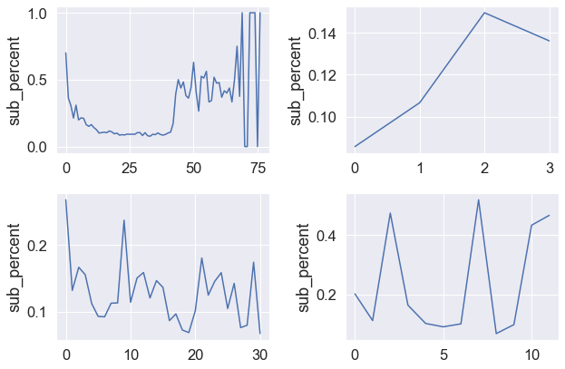

```python
fig,axes = plt.subplots(2,2)

grouped_age = train.groupby('age')['y'].agg([('sub_percent', 'mean'),('nobs','count')]).reset_index(drop=False)
sns.lineplot(ax=axes[0,0],x=grouped_age.index,y=grouped_age['sub_percent'])

grouped_education = train.groupby('education')['y'].agg([('sub_percent','mean'),('nobs','count')]).reset_index(drop=False)
sns.lineplot(ax=axes[0,1],x=grouped_education.index,y=grouped_education['sub_percent'])

grouped_day = train.groupby('day')['y'].agg([('sub_percent','mean'),('nobs','count')]).reset_index(drop=False)
sns.lineplot(ax=axes[1,0],x=grouped_day.index,y=grouped_day['sub_percent'])

grouped_month = train.groupby('month')['y'].agg([('sub_percent','mean'),('nobs','count')]).reset_index(drop=False)
sns.lineplot(ax=axes[1,1],x=grouped_month.index,y=grouped_month['sub_percent'])
```

```python
logit_model = smf.logit(formula='y~age+education+I(age**5)+I(age**7)+month+I(day**2)+I(day**4)+I(day**5)', data=train).fit()
logit_model.summary()
```

```
Optimization terminated successfully.
         Current function value: 0.330217
         Iterations 7
```

Logit Regression Results

| Dep. Variable: | y | No. Observations: | 35000 |
| --- | --- | --- | --- |
| Model: | Logit | Df Residuals: | 34979 |
| Method: | MLE | Df Model: | 20 |
| Date: | Sun, 26 Feb 2023 | Pseudo R-squ.: | 0.08635 |
| Time: | 18:52:07 | Log-Likelihood: | -11558. |
| converged: | True | LL-Null: | -12650. |
| Covariance Type: | nonrobust | LLR p-value: | 0.000 |

|  | coef | std err | z | P>\|z\| | [0.025 | 0.975] |
| --- | --- | --- | --- | --- | --- | --- |
| Intercept | 0.2595 | 0.171 | 1.519 | 0.129 | -0.075 | 0.594 |
| education[T.secondary] | 0.3586 | 0.060 | 6.004 | 0.000 | 0.242 | 0.476 |
| education[T.tertiary] | 0.6546 | 0.062 | 10.530 | 0.000 | 0.533 | 0.776 |
| education[T.unknown] | 0.4782 | 0.098 | 4.885 | 0.000 | 0.286 | 0.670 |
| month[T.aug] | -0.6970 | 0.071 | -9.769 | 0.000 | -0.837 | -0.557 |
| month[T.dec] | 1.0829 | 0.167 | 6.497 | 0.000 | 0.756 | 1.410 |
| month[T.feb] | -0.3339 | 0.087 | -3.819 | 0.000 | -0.505 | -0.163 |
| month[T.jan] | -0.8056 | 0.120 | -6.733 | 0.000 | -1.040 | -0.571 |
| month[T.jul] | -0.8883 | 0.072 | -12.290 | 0.000 | -1.030 | -0.747 |
| month[T.jun] | -0.7292 | 0.077 | -9.503 | 0.000 | -0.880 | -0.579 |
| month[T.mar] | 1.2194 | 0.120 | 10.195 | 0.000 | 0.985 | 1.454 |
| month[T.may] | -1.1789 | 0.066 | -17.804 | 0.000 | -1.309 | -1.049 |
| month[T.nov] | -0.7640 | 0.083 | -9.221 | 0.000 | -0.926 | -0.602 |
| month[T.oct] | 0.9146 | 0.102 | 8.980 | 0.000 | 0.715 | 1.114 |
| month[T.sep] | 0.9959 | 0.115 | 8.685 | 0.000 | 0.771 | 1.221 |
| age | -0.0668 | 0.005 | -14.507 | 0.000 | -0.076 | -0.058 |
| I(age ** 5) | 4.656e-09 | 3.46e-10 | 13.436 | 0.000 | 3.98e-09 | 5.33e-09 |
| I(age ** 7) | -4.881e-13 | 4.47e-14 | -10.925 | 0.000 | -5.76e-13 | -4.01e-13 |
| I(day ** 2) | 0.0009 | 0.001 | 1.477 | 0.140 | -0.000 | 0.002 |
| I(day ** 4) | -6.941e-06 | 2.78e-06 | -2.497 | 0.013 | -1.24e-05 | -1.49e-06 |
| I(day ** 5) | 1.971e-07 | 7.24e-08 | 2.721 | 0.007 | 5.51e-08 | 3.39e-07 |

```python
cm = confusion_matrix_train(logit_model,cutoff=0.124)
```

```
Classification accuracy = 75.2%
```

```python
confusion_matrix_data(train,train.y,logit_model,cutoff=0.124)
```

```
TPR or Recall = 50.8%
```

```python
def confusion_matrix_data(data,actual_values,model,cutoff=0.5):
#Predict the values using the Logit model
    pred_values = model.predict(data)
# Specify the bins
    bins=np.array([0,cutoff,1])
#Confusion matrix
    cm = np.histogram2d(actual_values, pred_values, bins=bins)[0]
    cm_df = pd.DataFrame(cm)
    cm_df.columns = ['Predicted 0','Predicted 1']
    cm_df = cm_df.rename(index={0: 'Actual 0',1:'Actual 1'})
# Calculate the accuracy
    accuracy = (cm[0,0]+cm[1,1])/cm.sum()
    #fnr = (cm[1,0])/(cm[1,0]+cm[1,1])
    #precision = (cm[1,1])/(cm[0,1]+cm[1,1])
    #fpr = (cm[0,1])/(cm[0,0]+cm[0,1])
    tpr = (cm[1,1])/(cm[1,0]+cm[1,1])
    #fpr_roc, tpr_roc, auc_thresholds = roc_curve(actual_values, pred_values)
    #auc_value = (auc(fpr_roc, tpr_roc))# AUC of ROC
    sns.heatmap(cm_df, annot=True, cmap='Blues', fmt='g')
    plt.ylabel("Actual Values")
    plt.xlabel("Predicted Values")
    print("Classification accuracy = {:.1%}".format(accuracy))
    #print("Precision = {:.1%}".format(precision))
    print("TPR or Recall = {:.1%}".format(tpr))
    #print("FNR = {:.1%}".format(fnr))
    #print("FPR = {:.1%}".format(fpr))
    #print("ROC-AUC = {:.1%}".format(auc_value))
```

```
Classification accuracy = 75.8%
TPR or Recall = 50.8%
```

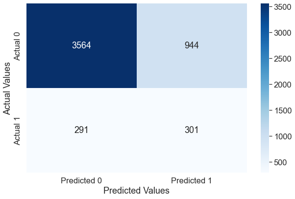

```python
confusion_matrix_data(test1,test1.y,logit_model,cutoff=0.124)
```

```
Classification accuracy = 75.1%
TPR or Recall = 51.9%
```

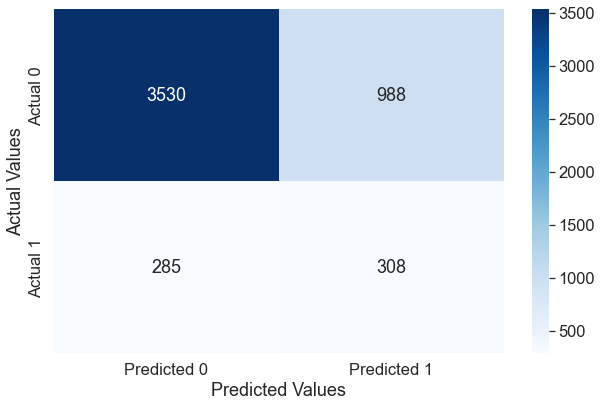

```python
confusion_matrix_data(test2,test2.y,logit_model,cutoff=0.124)
```

## D.14 ROC-AUC

Report the probability that the model will predict a higher probability of response for a customer who signs up for the term deposit as compared to the customer who does not sign up, i.e., the ROC-AUC of the developed model in D.13.

*Hint:* Use the functions `roc_curve`, and `auc` from the `sklearn.metrics` module

*(3 points)*

```
0.6952367845960996
```

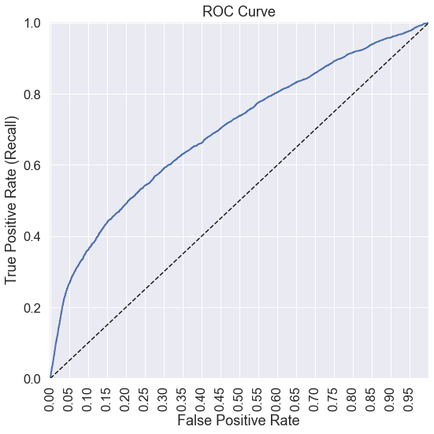

```python
from sklearn.metrics import roc_curve, auc
y=train.y
ypred = logit_model.predict(train)
fpr, tpr, auc_thresholds = roc_curve(y, ypred)
print(auc(fpr, tpr))# AUC of ROC
def plot_roc_curve(fpr, tpr, label=None):
    plt.figure(figsize=(8,8))
    plt.title('ROC Curve')
    plt.plot(fpr, tpr, linewidth=2, label=label)
    plt.plot([0, 1], [0, 1], 'k--')
    plt.axis([-0.005, 1, 0, 1.005])
    plt.xticks(np.arange(0,1, 0.05), rotation=90)
    plt.xlabel("False Positive Rate")
    plt.ylabel("True Positive Rate (Recall)")

fpr, tpr, auc_thresholds = roc_curve(y, ypred)
plot_roc_curve(fpr, tpr)
```

#### The probability that the model withh a predict a higher probability of response for a customer who does sign up for a term deposit as compared to a customer who does not sign up is 69.52%

## D.15 Net-profit

Suppose that the model developed in D.13 is used to predict the clients in *test1.csv* and *test2.csv* who will respond positively to the campaign. Only those clients who are predicted to respond positively are called during the marketing campaign. Assume that:

1. A profit of \$100 is associated with a client who responds positively to the campaign,
2. A loss of \$10 is associated with a client who responds negatively to the campaign

What is the net profit from the campaign? Use the confusion matrices printed in D.13.

*(4 points)*

```
Classification accuracy = 75.8%
TPR or Recall = 50.8%
```

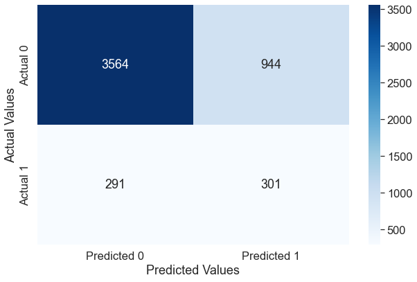

```python
confusion_matrix_data(test1,test1.y,logit_model,cutoff=0.124)
```

```python
net_profit1 = (301*100)-(944*10)
net_profit1
```

```
20660
```

```
Classification accuracy = 75.1%
TPR or Recall = 51.9%
```

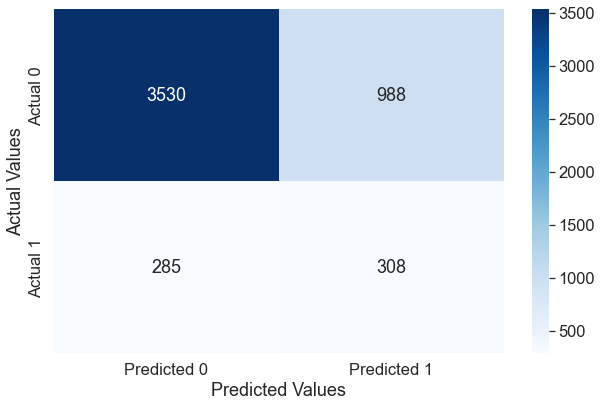

```python
confusion_matrix_data(test2,test2.y,logit_model,cutoff=0.124)
```

```python
net_profit2 = (308*100)-(988*10)
net_profit2
```

```
20920
```

```python
total_net_profit = net_profit1 + net_profit2
total_net_profit
```

```
41580
```

## D.16 Decision threshold probability

Based on the profit and loss associated with client responses specified in D.15, and the model developed in D.13, find the decision threshold probability of classification, such that the net profit is maximized. Use *train.csv*

Proceed as follows:

1. You would have obtained FPR and TPR for all potential decision threshold probabilities in D.14.
2. Formulate an expression quantifying the net profit per client *(among all the clients called in the marketing campaign)*, in terms of FPR, TPR, and the overall response rate, i.e., proportion of people actually subscribing to the term deposit.
3. Find the decision threshold probability that maximizes the expression in (2).

*(5 points)*

```python
profit_df = pd.DataFrame({'fpr':fpr, 'tpr':tpr, 'auc_threshold':auc_thresholds})
train['y'].value_counts()
```

```
0    30896
1     4104
Name: y, dtype: int64
```

```python
profit_df['net_profit'] = ((4104*profit_df['tpr']*100) - (30896*profit_df['fpr']*10))/4014
```

```python
df_sorted = profit_df.sort_values(by='net_profit', ascending=False)
df_sorted.head()
```

|  | fpr | tpr | auc_threshold | net_profit |
| --- | --- | --- | --- | --- |
| 4769 | 0.354221 | 0.634747 | 0.103267 | 37.633284 |
| 4720 | 0.349754 | 0.631335 | 0.104001 | 37.628301 |
| 4705 | 0.348168 | 0.630117 | 0.104163 | 37.625810 |
| 4721 | 0.349786 | 0.631335 | 0.103990 | 37.625810 |
| 4773 | 0.354674 | 0.634990 | 0.103216 | 37.623318 |

## D.17 Net profit based on new decision threshold probability

Using the new decision threshold probability obtained in D.16, answer D.15, i.e., what is the net-profit associated with the clients in *test1.csv* and *test2.csv* if a marketing campaign is performed. Again, only those clients who are predicted to respond positively, based on the new decision threshold probability, are called during the marketing campaign

Also, print the confusion matrices for predictions on *test1.csv* and *test2.csv* with the new threshold probability.

*(4 points)*

```
Classification accuracy = 64.9%
TPR or Recall = 63.0%
```

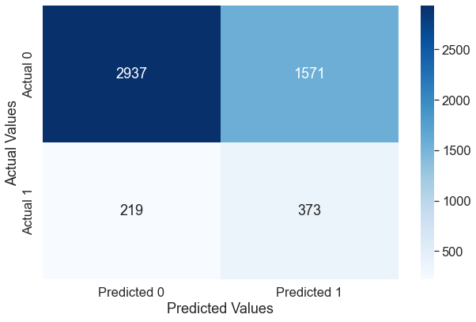

```python
confusion_matrix_data(test1,test1.y,logit_model,cutoff=0.103267)
```

```python
net_profit1 = (373*100)-(1571*10)
net_profit1
```

```
21590
```

```
Classification accuracy = 64.9%
TPR or Recall = 64.8%
```

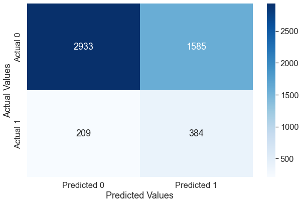

```python
confusion_matrix_data(test2,test2.y,logit_model,cutoff=0.103267)
```

```python
net_profit2 = (384*100)-(1585*10)
net_profit2
```

```
22550
```

```python
net_profit1+net_profit2
```

```
44140
```

## D.18 Model preference

Was the classification accuracy of the model in D.13 higher than that of the model in D.17? If yes, then should you prefer the model in D.13 for the marketing campaingn? Why or why not?

*Note: The model in D.17 is the same as in D.13, except with a different decision threshold probability*

*(3 points)*

#### The classification accuarcy was higher with the original threshold proposed in D.13. However, the model in D.17 is preffered because maximixing profits should be the priority of the marketing campaign. Because the profit gained from correctly calling someone is ten times greater than the loss of incorrectly calling someone, it is beneficial to priortize maximizing the TPR while also picking some more false positives in the process.

## D.19 ROC curve

Plot the ROC curve for the model developed in D.13. Mark the point on the curve corresponding the decision threshold probability identified in D.16.

*Note that the ROC curve is independent of the decision threshold probability used by the model for prediction*

*(3 points)*

```python
df_sorted.head(1)
```

|  | fpr | tpr | auc_threshold | net_profit |
| --- | --- | --- | --- | --- |
| 4769 | 0.354221 | 0.634747 | 0.103267 | 37.633284 |

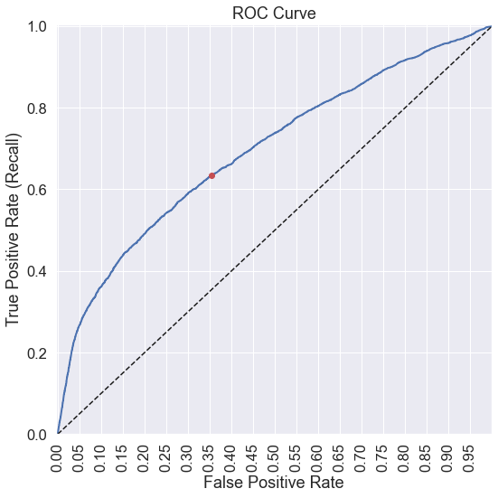

```python
plot_roc_curve(fpr,tpr)
plt.plot(0.354221,0.634747,"ro")
```

## D.20 Profit with TPR / FPR

Make a scatterplot of TPR vs FPR, and color the points based on net profit per client.

You can use the following code to make the plot if you have the relevant metrics in `tpr`, `fpr`, and `net_profit`

*(1 point)*

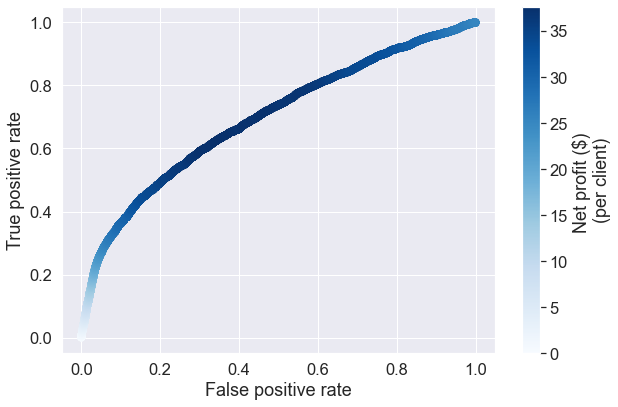

```python
import matplotlib.pyplot as plt
import seaborn as sns
sns.set(font_scale=1.5)
plt.rcParams["figure.figsize"] = (9,6)
plt.rcParams["figure.autolayout"] = True
f, ax = plt.subplots()
points = ax.scatter(fpr, tpr, c = profit_df['net_profit'], s=50, cmap="Blues")
f.colorbar(points, label = "Net profit ($) \n(per client)")
plt.xlabel("False positive rate")
plt.ylabel("True positive rate")
plt.show()
```

## D.21 Precision-recall

Compare the precision and recall of the models in D.13 and D.17 on *train.csv*.

*Note: The model in D.17 is the same as in D.13, except with a different decision threshold probability*

*(4 points)*

```python
cm1 = confusion_matrix_train(logit_model,cutoff = 0.124)
```

```
Classification accuracy = 75.2%
```

```python
precision = 2085/(2089+6659)
recall = 2085/(2085+2019)
print(precision,",",recall)
```

```
0.23834019204389575 , 0.5080409356725146
```

```
Classification accuracy = 64.4%
```

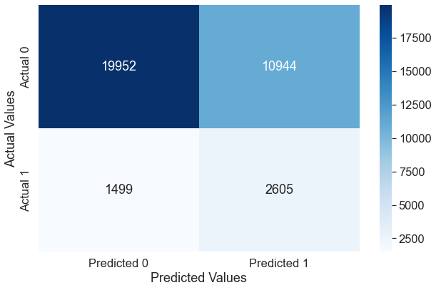

```python
cm2 = confusion_matrix_train(logit_model, cutoff = 0.103267)
```

```python
precision = 2605/(2605+10944)
recall = 2605/(2605+1499)
print(precision,",",recall)
```

```
0.1922651118163702 , 0.6347465886939572
```

#### Precision is higher for the model with the original cutoff. Recall is higher for the model with the new cutoff.

## D.22 Precision-recall: important metric

Based on the above comparison, which metric among precision and recall turns out to be more important for maximizing the net profit in the marketing campaign?

#### Recall is the most important as it represents the ability of the model to capture all of the actual positives. A higher recall means that more people would actually suscbribe are called than not called, increasing the amount of 100 dollar profits the marketing campain generates.

*(1 point)*

## D.23 Precision-recall curve

Plot the precision-recall curve vs decision threshold probability for the model developed in D.13. Mark the points on the curve corresponding to the decision threshold probability identified in D.16.

*(3 points)*

```python
from sklearn.metrics import precision_recall_curve
def plot_precision_recall_vs_threshold(precisions, recalls, thresholds):
    plt.figure(figsize=(8, 8))
    plt.title("Precision and Recall Scores as a function of the decision threshold")
    plt.plot(thresholds, precisions[:-1], "b--", label="Precision")
    plt.plot(thresholds, recalls[:-1], "g-", label="Recall")
    plt.ylabel("Score")
    plt.xlabel("Decision Threshold")
    plt.legend(loc='best')
    plt.legend()
```

```python
y=train.y
ypred = logit_model.predict(train)
p, r, thresholds = precision_recall_curve(y, ypred)
```

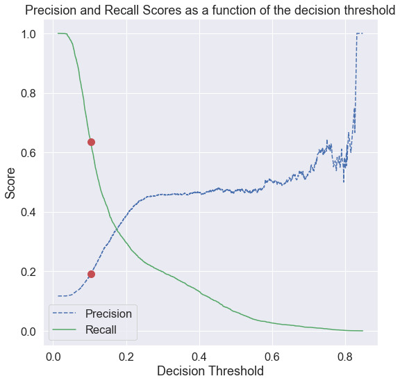

```python
def plot_precision_recall_vs_threshold(precisions, recalls, thresholds, x_value):
    plt.figure(figsize=(8, 8))
    plt.title("Precision and Recall Scores as a function of the decision threshold")
    plt.plot(thresholds, precisions[:-1], "b--", label="Precision")
    plt.plot(thresholds, recalls[:-1], "g-", label="Recall")
    plt.ylabel("Score")
    plt.xlabel("Decision Threshold")
    plt.legend(loc='best')

    # find the index of the threshold value closest to the x value
    idx = np.argmin(np.abs(thresholds - x_value))

    # plot the precision and recall points at the threshold value
    plt.plot(thresholds[idx], precisions[idx], 'ro', markersize=10)
    plt.plot(thresholds[idx], recalls[idx], 'ro', markersize=10)

    plt.legend()
    plt.show()

plot_precision_recall_vs_threshold(p, r, thresholds, 0.103267)
```

## D.24 Precision-recall vs FPR-TPR

Instead of using the FPR and TPR metrics to find the optimium decision threshold probability in D.16, used the precision-recall metrics to find the same.

*(5 points)*

```python
def plot_precision_recall_vs_threshold(precisions, recalls, thresholds):
    plt.figure(figsize=(8, 8))
    plt.title("Precision and Recall Scores as a function of the decision threshold")
    plt.plot(thresholds, precisions[:-1], "b--", label="Precision")
    plt.plot(thresholds, recalls[:-1], "g-", label="Recall")
    plt.ylabel("Score")
    plt.xlabel("Decision Threshold")
    plt.legend(loc='best')
    plt.legend()
y=train.y
ypred = logit_model.predict(train)
p, r, thresholds = precision_recall_curve(y, ypred)
pr_df = pd.DataFrame({"precision":p[:-1],"recall":r[:-1],"thresholds":thresholds})
pr_df
```

|  | precision | recall | thresholds |
| --- | --- | --- | --- |
| 0 | 0.117257 | 1.000000 | 0.013676 |
| 1 | 0.117232 | 0.999756 | 0.030948 |
| 2 | 0.117235 | 0.999756 | 0.031006 |
| 3 | 0.117239 | 0.999756 | 0.031068 |
| 4 | 0.117245 | 0.999756 | 0.031085 |
| ... | ... | ... | ... |
| 12680 | 0.600000 | 0.000731 | 0.815608 |
| 12681 | 0.750000 | 0.000731 | 0.825449 |
| 12682 | 0.666667 | 0.000487 | 0.826339 |
| 12683 | 1.000000 | 0.000487 | 0.831922 |
| 12684 | 1.000000 | 0.000244 | 0.848093 |

12685 rows × 3 columns

```python
### TPR = recall, find recall with same value as TPR in D.16
pr_df[pr_df['recall'] <= 0.634747].head(10)
```

|  | precision | recall | thresholds |
| --- | --- | --- | --- |
| 6305 | 0.192067 | 0.634747 | 0.103224 |
| 6306 | 0.192137 | 0.634747 | 0.103228 |
| 6307 | 0.192152 | 0.634747 | 0.103232 |
| 6308 | 0.192166 | 0.634747 | 0.103237 |
| 6309 | 0.192180 | 0.634747 | 0.103252 |
| 6310 | 0.192223 | 0.634747 | 0.103262 |
| 6311 | 0.192265 | 0.634747 | 0.103267 |
| 6312 | 0.192220 | 0.634503 | 0.103302 |
| 6313 | 0.192160 | 0.634259 | 0.103305 |
| 6314 | 0.192055 | 0.633772 | 0.103306 |

```python
#It should be the same as D.16?
```